# 501 Project

Valentina Zhong (63260335)

04/10/2021

# Background

Crude oil is not only a highly volatile commodity, in terms of chemical properties and risk associated with price fluctuation (Peng & Li, 2020, p. 4465), but also a vital element in global macroeconomics. Even though people are currently working hard on developing the alternate energy sourcing systems such as biofuel and hydrogen fuel and so on, petroleum still holds its place in many most important non-renewable energy resources in the world nowadays. Therefore, the prediction on the crude oil price around the world is essential. As law of one price is a most popular principle behind global trade, we will applied the law of one price to analyze the crude oil price between China (Importer) and the USA (exporter). Also, as exchange rate has a significant effect on the global market, the correlation analysis between crude oil and exchange rate will be developed.

# Literature Review

According to the conclusion from Dr. Giulietti, the oil physical/chemical characteristics as well as the membership of OPEC will affect the crude oil price of trading based on 32 different global crude oil traded. Also, the differential are follow the law of one price principle (Giulietti and Iregui, 2015). Based on her outcome, we will located in two specific countries and to see if the law of one price also applicable during the pandemic.

# Dataset

**Data for Market Analysis** - [UN Comtrade](https://comtrade.un.org/data/) for global market share analysis - [OECD](https://data.oecd.org/energy/crude-oil-import-prices.htm) choose Australia, Japan, South Korea, Germany, America and Netherlands for price variety analysis - [CEIC](https://insights-ceicdata-com.eu1.proxy.openathens.net/Untitled-insight/myseries) choose China for price variety analysis

**Data for Law of One Price Analysis**

- [Investing.com](https://www.investing.com/commodities/crude-oil) as export price from the USA
- [OECD](https://data.oecd.org/energy/crude-oil-import-prices.htm) choose Australia, Germany and Netherlands’ import price
- [CEIC](https://insights-ceicdata-com.eu1.proxy.openathens.net/Untitled-insight/myseries) choose China settlement price as import price
- [seadistance](https://sea-distances.org/) for shipping distance

**Data for Correlation Analysis**

- [Investing.com](https://www.investing.com/currencies/usd-cny) Factor: exchange rate between CNY and USD
- [Investing.com](https://www.investing.com/commodities/gold) Factor: gold price

# Roadmap and objectives

Firstly, we will use some visualization to show the mainly player in the crude oil market and the price changing along past 20 years

Secondly, we examines the relationship between shipping distance (in mile) and price spread (in USD). The shipping distances are collected from importing countries consist of Australia, China, German and Dutch, according to the data from OECD, Investing.com and CEIC in 2020. Also, a line graph is created to present the relationship between the movements in China and U.S.’ local crude oil futures prices, which is expected to help examine the degree of market integration. Given the deviation from what we would expect, the extended part of this section is developed with the collaboration of variables exchange rate and transportation cost in order to comprehend such anomaly.

Lastly, my team has run a few simple liner regressions to investigate the change rate in exchange rate and crude oil return, which deems to help further comprehend the exchange rate variable that is closely connected to various parts of this project.

Other than completed items listed above, the main objectives of this project are to provide and investigate, under Dr. Vercamman’s guidance, (1) the overview of global crude oil trade among major players, (2) how LOP applies in the syntax of crude oil industry and (3) how exchange rate interacts with crude oil futures prices for they are significant economic indicators.

```r
pacman::p_load(here, rjson, dplyr, ggplot2, gridExtra, kableExtra, comtradr, tidyverse, lubridate, ggthemes, ggrepel, cansim, janitor, gganimate, gifski, png, magrittr, SciViews, stargazer, texreg)
```

# Methodology

### 1. Market Analysis

**1.1 Import Shares**

A pie chard to illustrate the trading pattern among the United Stated (exporter) and a group of countries (importers) consist of China, South Korea, Italy and German, according to the data from UN comtrade in 2020.

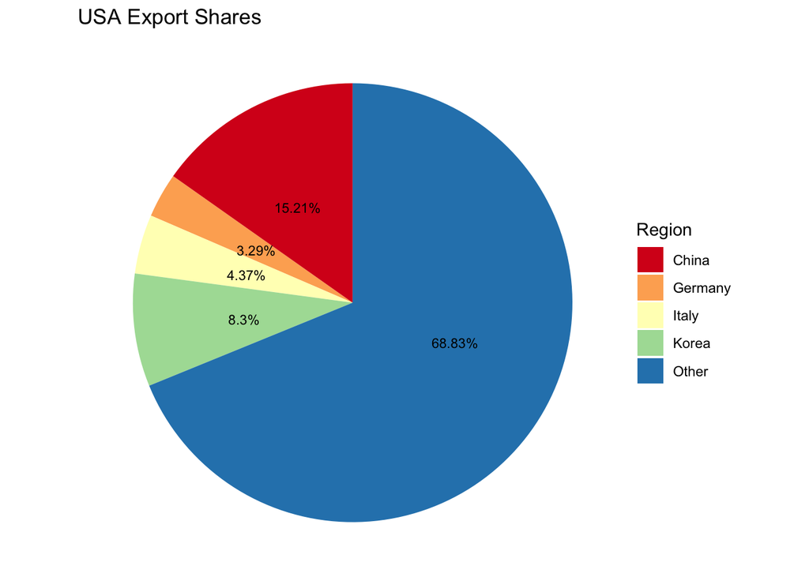

```r
dfA <- ct_search(reporters = "USA",
                 partners = c("China", "Rep. of Korea", "Italy", "Germany", "World"),
                 trade_direction = "exports",
                 start_date = "2020-01",
                 end_date = "2020-12",
                 commod_codes = c("270900"))

saveRDS(dfA, file = here("Data", "dfA.RDS"))
UNC <- readRDS(here("Data", "dfA.RDS"))

A_final <- dfA %>%
  mutate(Weight.A = as.numeric(qty)/1000,
         Unit.A = "tonnes") %>%
  select(partner, reporter, commodity_code, year, trade_flow, Unit.A, Weight.A) %>%
  rename(Exp.A = reporter,
         Imp.A = partner,
         Comm.A = commodity_code,
         Year.A = year,
         Type.A = trade_flow) %>%
  arrange(Weight.A)

A_final <- A_final %>%
  mutate(share = Weight.A / Weight.A[n()])

China <- A_final[4,"Weight.A"]
Germany <- A_final[1,"Weight.A"]
Italy <- A_final[2,"Weight.A"]
Korea <- A_final[3,"Weight.A"]
world <- A_final[5,"Weight.A"]
other <- world - (China + Germany + Italy + Korea)

USA_exports <- data.frame(region = c("China", "Germany", "Italy", "Korea", "Other", "World"),
                                exports = c(China, Germany, Italy, Korea, other, world))

USA_exports <- USA_exports %>%
  arrange(exports) %>%
  mutate(share = exports / exports[n()] * 100,
         labels = paste0(round(exports / exports[n()] * 100, 2), "%")) %>%
  filter(region != "World")

market_share <- ggplot(USA_exports, aes(x = "", y = share, fill = region)) +
  geom_bar(width = 1, stat = "identity") +
  coord_polar("y", start = 0) +
  geom_text(aes(label = labels), position = position_stack(vjust=0.45), size = 3) +
  labs(title = "USA Export Shares") +
  scale_fill_brewer(name = "Region", palette = "Spectral") +
  theme_void()

market_share
```

**1.2 Price Change Over Time in Different Countries**

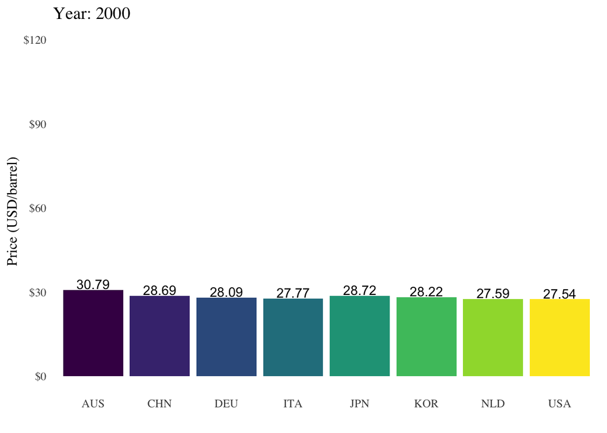

```r
Import_raw <- read.csv(here("Data", "Import price.csv"), header=TRUE, sep=",", stringsAsFactors = FALSE)
provlist <- c("CHN", "KOR", "JPN", "NLD", "AUS", "DEU", "ITA", "USA")

df_imp <- Import_raw %>%
  filter(LOCATION %in% provlist) %>%
  select(LOCATION, MEASURE, TIME, PRICE=Value)

plot_Impoter <- ggplot(df_imp, aes(LOCATION, PRICE, fill = LOCATION, label=PRICE)) +
  geom_col()

plot_imp <- plot_Impoter +
  geom_text(vjust=-0.1) +
  scale_fill_viridis_d() +
  scale_y_continuous(labels=scales::dollar) +
  theme_tufte(base_size = 12) +
  theme(legend.position = "none",
        axis.ticks = element_blank()) +
  labs(title = "Year: {frame_time}", x = "", y = "Price (USD/barrel)", )

plot_imp +
  transition_time(TIME)
```

### 2. The Law of One Price Analysis

The spatial law-of-one-price (LOP) will be also examined in the crude oil trade between China and the United State. For a homogeneous good, trade between two countries occurs when their price difference is the same as the transportation cost, which is LOP (Stigler and Sherwin, 1985).

**2.1 Price Difference V.S. Shipping Distance**

If the law of one price hold, the price gap between exporters and importers should increase as the shipment distance goes up. We chose China, Australia, Netherlands and Germany to examine whether the LOP holds or not, since they can represent three various shipping routes. From the table, the country whose shipping distance is greater its price difference tends to greater at the same time.Therefore, we can roughly conclude that the LOP holds in this case study.

```r
# create variable
US_exp_price <- 38.60

provlist2 <- c("CHN", "NLD", "AUS", "DEU")
imp_price <- Import_raw %>%
  filter(TIME == "2020",
         LOCATION %in% provlist2) %>%
  select(region=LOCATION, PRICE=Value)

Netherlands_dist <- 3411
Germany_dist <- 3785
China_dist <- 10638
Australia_dist <- 12873

# create df
imp_dist <- data.frame(region = c("AUS", "CHN", "DEU", "NLD"),
                          shipping_distance = c(Australia_dist, China_dist, Germany_dist, Netherlands_dist))

# create table
pdiff_distance <- imp_dist %>%
  mutate(import_price = as.numeric(imp_price$PRICE),
         export_price_US = US_exp_price,
         price_diff = import_price-export_price_US) %>%
  select(region, import_price, export_price_US, price_diff,shipping_distance) %>%
  arrange(price_diff)

pdiff_distance <- pdiff_distance %>%
  kbl() %>%
  kable_material(c("striped", "hover"))

pdiff_distance
```

| region | import_price | export_price_US | price_diff | shipping_distance |
| --- | --- | --- | --- | --- |
| NLD | 42.38 | 38.6 | 3.78 | 3411 |
| DEU | 43.24 | 38.6 | 4.64 | 3785 |
| CHN | 44.85 | 38.6 | 6.25 | 10638 |
| AUS | 50.21 | 38.6 | 11.61 | 12873 |

**2.2 CNY Price Versus USD Price**

For the further analysis on the LOP and the exchange rate effect, local price in China and USD were extracted to compared. Both of them are the price from local future exchanges, which will assist in reducing the bias. `CHN_local` was created to store the data of China and `US_local` stored the data of the United States. `plot_china` and `plot_USA` render the line graph of China and America separately.

With the comparing of these two graph, the movement and tendency of the price in CNY are similar to the changing of price in USD. The dramatic decreasing of the crude oil price in first half of 2020 is shown in both countries. However, the extents of fluctuations are not the same exactly, which means there are similar but not perfect match. Mr. Kaufmann and Mr. Banerjee explained the global market and price difference from various countries cloud be infludenced by physical, technical, political and economic barriers (2014), which can also indicate there are differences in the movement of crude oil price from various countries’ markets. Besides the factors mentioned by Mr. Kaufmann and Mr. Banerjee, we will try to use the movement of exchange rate to explained those variance.

It is interesting that this model can not only explain the law of one price is efficient in this study case but also relate to comment of pricing integration. In Module 1D, we know LOP is a significant assumption to pricing integration. Even their price movement are not exactly the same, it still represent pricing integration to a certain degree.

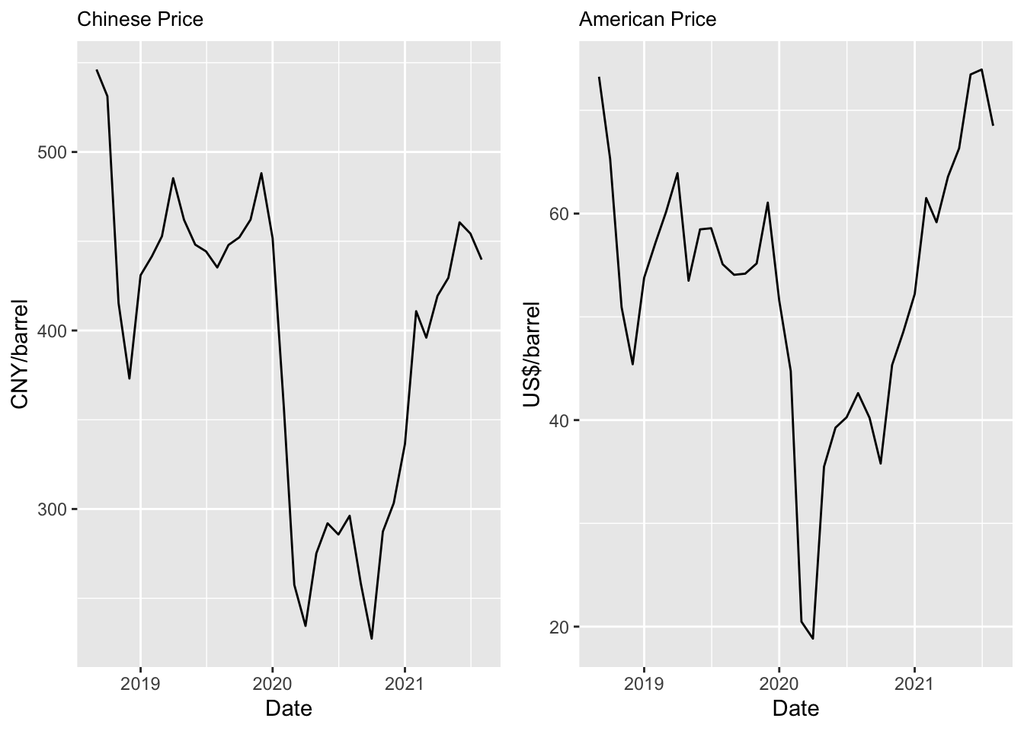

```r
# load data
CHN_local <- read.csv(here("Data", "CN settlement price SH Furture Exchanges.csv"), header=TRUE, sep=",", stringsAsFactors = FALSE)
CHN_local$Date <- seq(as.Date("2018/9/1"), by = "month", length.out = 36)
US_local <- read.csv(here("Data", "US Crude Oil WTI Futures.csv"), header=TRUE, sep=",", stringsAsFactors = FALSE)
US_local$Date <- seq(as.Date("2018/9/1"), by = "month", length.out = 36)
US_local <- US_local %>%
  select(Date, Price)

# Create a data frame for price comparison analysis
dfcu <- CHN_local %>%
  mutate(US_price = US_local$Price,
         CHN_price = Price) %>%
  select(Date, CHN_price, US_price)

# Plot the two price series side by side
plot_china <- ggplot(CHN_local, aes(x = Date, y = Price)) +
  geom_line() +
  labs(title = "Chinese Price", y= "CNY/barrel", x = "Date") +
  theme(plot.title = element_text(size=10))

plot_USA <- ggplot(US_local, aes(x = Date, y = Price)) +
  geom_line() +
  labs(title = "American Price", y = "US$/barrel", x = "Date") +
  theme(plot.title = element_text(size=10))

grid.arrange(plot_china, plot_USA, ncol = 2)
```

**2.3 Analysis of Price Spread with Law of One Price**

There may be almost 30% of the price difference can be explained by the transportation cost (Giulietti and Iregui, 2015). To test if the LOP hold exactly, we decided to analyze the price spread and calculate the arithmetic mean of the price spread to compared with the transportation cost. The data of price spread is irregular after 2020, which can be seen in the first picture.

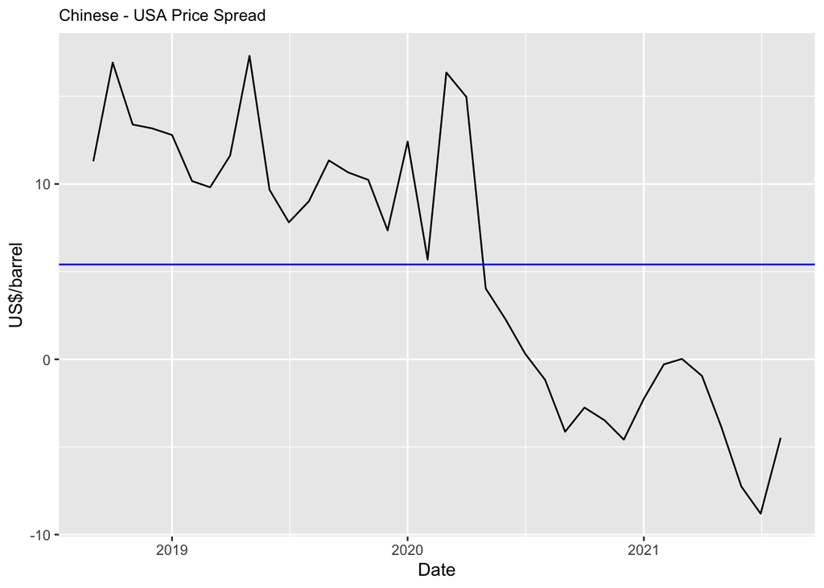

```r
# Import exchange rate data
exchange_rate <- read.csv(here("Data", "USD_CNY Data.csv"), header=TRUE, sep=",", stringsAsFactors = FALSE)
exchange_rate$Date <- seq(as.Date("2018/9/1"), by = "month", length.out = 36)
exchange_rate <- exchange_rate %>%
  select(Date, exchange_rate = Price)

# Create a table contained price ratio and exchange rate
pr_er <- dfcu %>%
  mutate (priceRatio = CHN_price/US_price,
          exchangeRate = exchange_rate$exchange_rate)
# Analysis of Price Spread
priceSpread <- mutate(pr_er, spread = (CHN_price/exchangeRate - US_price))

plot_Spread <- ggplot(priceSpread, aes(x = Date, y = spread)) +
  geom_line() +
  labs(title = "Chinese - USA Price Spread", y= "US$/barrel", x = "Date") +
  theme(plot.title = element_text(size=10)) +
  geom_hline(yintercept = mean(priceSpread$spread), color="blue")
plot_Spread
```

```r
# focus on the data before April 2020
priceSpread2 <- priceSpread %>%
  slice(1:20)
```

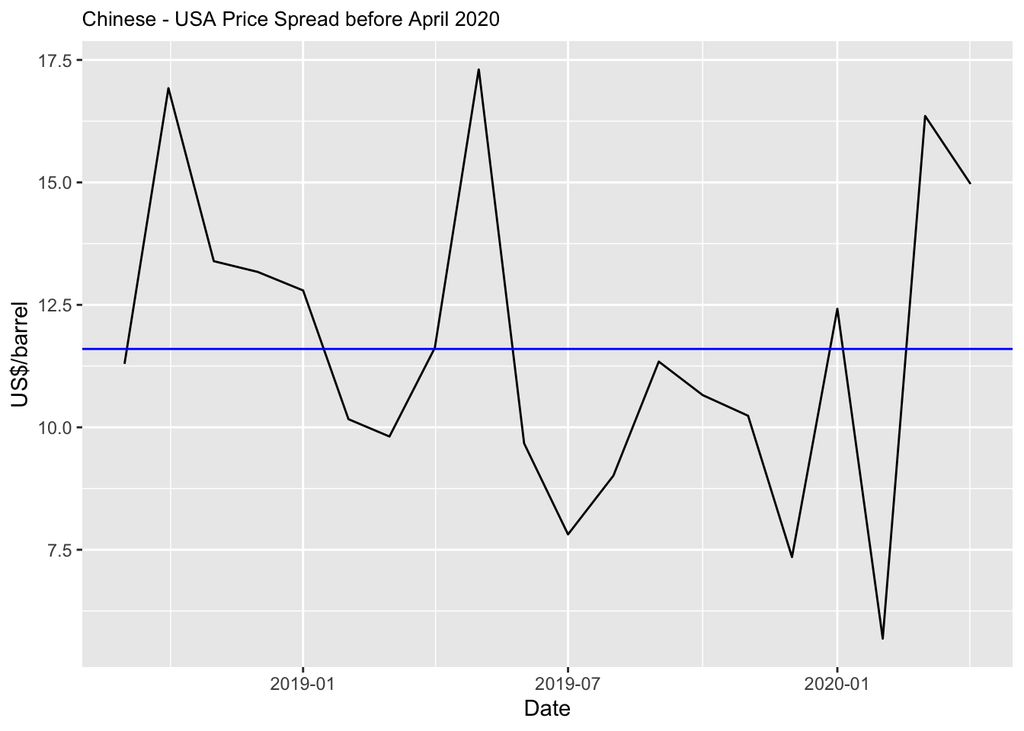

```r
plot_Spread2 <- ggplot(priceSpread2, aes(x = Date, y = spread)) +
  geom_line() +
  labs(title = "Chinese - USA Price Spread before April 2020", y= "US$/barrel", x = "Date") +
  theme(plot.title = element_text(size=10)) +
  geom_hline(yintercept = mean(priceSpread2$spread), color="blue")
plot_Spread2
```

```r
# It is almost the same as the data reported of Bloomberg in the trade war
```